# 02 – Introduction to RDKit

Authored by: *Fredrik Svensson, Oliver Scott*  
Edited by: *Florion Peni*

You can use the links in the Contents section to navigate the notebook.

Please ensure you complete `01_python_introduction.ipynb` before proceeding with the RDKit-focused content in this notebook. If you are already familiar with Python basics, you may skip the introduction and continue with this material.

⚠️ **Please run the code cells in order**. Skipping cells may result in errors due to missing variables or imports.

### What is RDKit?

**RDKit** is an open-source cheminformatics and machine-learning toolkit written in C++ and Python.  
It provides powerful tools for computational chemistry and molecular modelling.

### What will we learn?

RDKit is a comprehensive toolkit with too many functions to cover in a single session. To make learning manageable, we have selected a set of essential utilities frequently used by computational chemists. These topics are organised into notebooks:

- **reading and writing molecular structures**: `02_rdkit_introduction.ipynb`,
- **working with molecular structures**: `02_rdkit_introduction.ipynb`,
- **substructure searching and filtering**: `03_rdkit_substructure.ipynb`,
- and **molecular similarity**: `04_rdkit_similarity.ipynb`.

In this notebook, we will cover the basics of RDKit, focusing on how to read, write, and manipulate molecular structures. For further learning, explore the [official RDKit Documentation](http://rdkit.org/docs/index.html).

### JupyterLab / Google Colab

**JupyterLab** is an open-source interface for running and sharing notebooks with code and text.  
**Google Colab** is a cloud-based version of Jupyter that runs in your browser and connects to free GPUs and TPUs.

> *When working in Colab, any files saved in the runtime (e.g. downloaded datasets or generated outputs) are temporary and will be deleted when you close the tab or your session times out.*

You can view runtime files by clicking the folder icon in the left-hand toolbar. If you are working with important files, make sure to download them to your local machine or save them to Google Drive before ending your session.

> If you make edits to this notebook and would like to save them you can save your own copy by clicking on **File > Save a copy in Drive** in the top menu. This ensures your work is preserved even after you close the runtime.

### Writing and running code

You can write and run Python code inside **code cells**.

First, select it by clicking on it. Then:

- Click the run/play button located inside the cell (in Colab) or in the toolbar above (in JupyterLab), or
- Use these keyboard shortcuts:
  - Windows: `Ctrl` + `Enter`
  - macOS: `⌘ Command` + `Enter`

> When you first run code on this notebook in Google Colab, you may see a message like:

*“This notebook was not authored by Google. It may request access to your data…”*  
This is expected for notebooks loaded from GitHub. Click the *“Run anyway”* button when prompted to start running the code.

## Contents

> Internal markdown links (like the ones below) may not work reliably in Colab. To navigate the notebook, use the **Table of contents** panel: click the first icon in the left-hand toolbar.
- Using RDKit
- Molecular representation
- Molecular descriptors
- Reading molecules from files
- Conformers
- Discussion

## Using RDKit

To access RDKit’s functionality, we first need to import it. Most of the core utilities are available within the `Chem` package:

```
from rdkit import Chem
```

If you encounter an error during the import, it may indicate that RDKit was not installed correctly.

> **RDKit is not pre-installed in Google Colab.** The code below checks if you're in the Colab environment and installs RDKit using `!pip` prior to importing it.

> **If you're running this notebook locally in JupyterLab (e.g. via Anaconda)**, RDKit should already be installed as part of the environment setup. The code detects you are not in Colab and skips to the import command.

⚠️ Reach out for assistance with resolving installation issues.

```python
# Checks if running in Google Colab
try:
    import google.colab
    IN_COLAB = True
except ImportError:
    IN_COLAB = False

# Install RDKit if in Colab
if IN_COLAB:
    print("Installing RDKit for Colab. May take a few seconds...")
    !pip install rdkit -q
    print("Installation complete.")

# Import RDKit
from rdkit import Chem
```

We can now access many useful functions.

## Molecular representation

In cheminformatics, chemical structures can be represented in a variety of ways. RDKit supports reading and working with many of these representations.

### SMILES (Simplified Molecular Input Line Entry Specification)

SMILES is a widely used text-based representation of molecules.

- Atoms are represented by their atomic symbols (e.g. C, O, F, Br, etc.).
- Double bonds are represented by `=`.
- Triple bonds are represented by `#`.
- Rings are represented by matching pairs of digits (e.g., benzene: `c1ccccc1`).
- Branching is indicated using parentheses.

The figure below shows how the SMILES for **Ciprofloxacin**, a fluoroquinolone antibiotic, is retrieved.

[figure not shown]

[Image source](https://miro.medium.com/v2/resize:fit:1400/1*tuXqpPuKO9PBPwUx5jz5Nw.png)

For the full SMILES specification, refer to the [Daylight website](https://www.daylight.com/dayhtml/doc/theory/theory.smiles.html).

Using RDKit, we can read SMILES strings with the `Chem.MolFromSmiles()` function.

```python
smiles_1 = 'CC(=O)OC1=CC=CC=C1C(O)=O'   # This is the SMILES for Aspirin
aspirin = Chem.MolFromSmiles(smiles_1)  # The molecule is loaded into an RDKit `Mol` object

print(aspirin)
```

```
<rdkit.Chem.rdchem.Mol object at 0x16be7f8b0>
```

Displaying a molecule as plain text is not particularly helpful. Instead, visualising the molecule as an image is much more informative.

You can view molecules inline simply by typing the variable that holds the molecule and running the cell.

Note: *If this feature does not work, include the following line at the top of the cell before running it:*

```
from rdkit.Chem.Draw import IPythonConsole
```

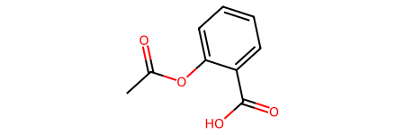

```python
aspirin  # Running this cell should return the chemical structure of Aspirin
```

If we want to display multiple molecules at the same time we need to use the `Draw` module.  
Let's try visualising two molecules using the `Draw.MolsToGridImage()` function.

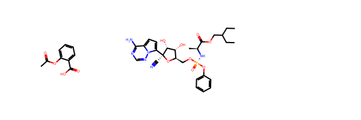

```python
from rdkit.Chem import Draw

# This is the SMILES for Remdesivir, an antiviral medicine for the treatment of COVID-19
smiles_2 = 'CCC(CC)COC(=O)[C@H](C)N[P@](=O)(OC[C@@H]1[C@H]([C@H]([C@](O1)(C#N)C2=CC=C3N2N=CN=C3N)O)O)OC4=CC=CC=C4'
remdesivir = Chem.MolFromSmiles(smiles_2)

# Draw Aspirin and Remdesivir together
mols = [aspirin, remdesivir]  # The function expects the molecules to be in a list
Draw.MolsToGridImage(mols)
```

We can also add legends.

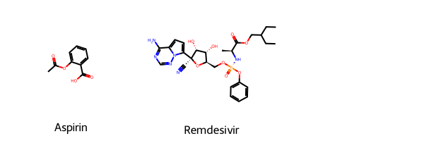

```python
Draw.MolsToGridImage(mols, legends=['Aspirin', 'Remdesivir'])
```

### Structure data format (SDF) file

Information about a molecule's structure can be stored in an **SDF file**, a type of [chemical table file](https://en.wikipedia.org/wiki/Chemical_table_file). These files are widely used in computational chemistry to represent molecular data, including atom types, coordinates, and bonds.

Below, the **phenol** molecule is encoded as a MolBlock, a specific format compatible with RDKit. The MolBlock encodes:

1. **atom types** - specifies the types of atoms in the molecule (e.g. carbon `C` and oxygen `O`),
2. **atomic positions** - defines the 2D or 3D coordinates of each atom in space,
3. and **connectivity and bond types** - indicates how the atoms are connected (single, double, or other bond types).

We can assign this data to a variable, e.g. `molblock`.

Using RDKit, we can read this data and create a molecular representation using the `Chem.MolFromMolBlock()` function. Once loaded, the resulting object, `phenol`, can be used for further analysis or visualisation.

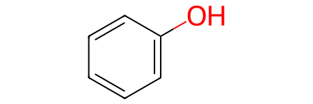

```python
# Define the MolBlock representation of the phenol molecule
molblock = """phenol
  Mrv1682210081607082D

  7  7  0  0  0  0            999 V2000
   -0.6473    1.0929    0.0000 C   0  0  0  0  0  0  0  0  0  0  0  0
   -1.3618    0.6804    0.0000 C   0  0  0  0  0  0  0  0  0  0  0  0
   -1.3618   -0.1447    0.0000 C   0  0  0  0  0  0  0  0  0  0  0  0
   -0.6473   -0.5572    0.0000 C   0  0  0  0  0  0  0  0  0  0  0  0
    0.0671   -0.1447    0.0000 C   0  0  0  0  0  0  0  0  0  0  0  0
    0.0671    0.6804    0.0000 C   0  0  0  0  0  0  0  0  0  0  0  0
    0.7816    1.0929    0.0000 O   0  0  0  0  0  0  0  0  0  0  0  0
  1  2  1  0  0  0  0
  2  3  2  0  0  0  0
  3  4  1  0  0  0  0
  4  5  2  0  0  0  0
  5  6  1  0  0  0  0
  1  6  2  0  0  0  0
  6  7  1  0  0  0  0
M  END
"""

# Load the molecule into an RDKit object
phenol = Chem.MolFromMolBlock(molblock)

# Display the object
phenol
```

## Molecular descriptors

Now that we have three molecules we can find out some more descriptive information about them.  
RDKit has a number of built-in functions that can be used to extract information from our molecules.

```python
# We can use the `.GetNumAtoms()` method to get the number of atoms in the molecule
print('Phenol has', phenol.GetNumAtoms(), 'atoms')
```

```
Phenol has 7 atoms
```

#### Exercise 1: Reading molecules

Using the SMILES string for **Acetaminophen** from its [PubChem entry](https://pubchem.ncbi.nlm.nih.gov/compound/1983#section=SMILES), complete the following tasks:

1. Load the molecule into an RDKit `Mol` object.
2. Print the number of atoms in the molecule.
3. Print the number of bonds in the molecule.
4. Draw the structure of the molecule.

```python
# Add your solution code here
```

We can use the `Descriptors` module from the `Chem` package in RDKit to access a variety of molecular descriptors. These provide valuable information about a molecule's physical, chemical, and structural properties.

> Molecular descriptors can be used for:
> - **filtering compounds** - narrowing down a large set of molecules based on specific properties,
> - and **building statistical models** - predicting activities of compounds toward biological targets or other chemical behaviors.

Descriptors like molecular weight, logP, or topological polar surface area (TPSA) are commonly used in cheminformatics workflows.

```
Salbutamol
-----------
Heavy atoms: 17
H-bond donors: 4
H-bond acceptors: 4
Molecular weight: 239.315 g/mol
LogP: 1.3059999999999998
TPSA: 72.72
```

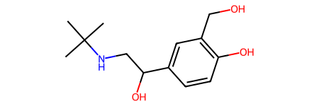

```python
from rdkit.Chem import Descriptors

smiles = 'CC(C)(C)NCC(O)C1=CC(CO)=C(O)C=C1'  # This is the SMILES for Salbutamol
salbutamol = Chem.MolFromSmiles(smiles)

# Calculate some interesting descriptors
print('Salbutamol' + '\n' + '-' * 11)
print('Heavy atoms:', Descriptors.HeavyAtomCount(salbutamol))
print('H-bond donors:', Descriptors.NumHDonors(salbutamol))
print('H-bond acceptors:', Descriptors.NumHAcceptors(salbutamol))
print('Molecular weight:', Descriptors.MolWt(salbutamol), 'g/mol')
print('LogP:', Descriptors.MolLogP(salbutamol))
print('TPSA:', Descriptors.TPSA(salbutamol))

salbutamol
```

In **JupyterLab**: Uncomment the line below, place your cursor just after the `.` and press the `Tab` key. This will display an interactive list of all available functions and attributes from the module.

In **Google Colab**: Uncomment the line below, place your cursor after the `.` and begin typing (e.g. "mo..."). Colab will automatically display a list of suggested functions based on what you've typed.

```python
# Descriptors.
```

#### Exercise 2: Molecular descriptors

Using the SMILES string for **Celecoxib** from its [PubChem entry](https://pubchem.ncbi.nlm.nih.gov/compound/2662#section=SMILES), complete the following tasks:

1. Load the molecule into an RDKit `Mol` object.
2. Calculate and print five different molecular descriptors for it.
3. Draw the structure of the molecule.

```python
# Add your solution code here
```

## Reading molecules from files

SDF files can store multiple molecules separated by `$$$$`. Instead of reading and assigning each molecule individually, we can load all the molecules at once.

Within the tutorial folder, `RDKitTutorial`, we have included a subdirectory called `data`. Inside this folder, there is a file named `approved_drugs.sdf`, which contains a collection of approved drugs.

We can read SDF files with multiple molecules using the `Chem.SDMolSupplier()` function.

Note: *You may encounter some warnings from RDKit, which can safely be ignored.*

```python
import os

# Check if running on Colab
try:
    import google.colab
    IN_COLAB = True
except ImportError:
    IN_COLAB = False

# Set file path based on environment
if IN_COLAB:
    approved_drugs_file = 'data/approved_drugs.sdf'
else:
    approved_drugs_file = '../data/approved_drugs.sdf'

# If running in Colab, download the file
if IN_COLAB and not os.path.exists(approved_drugs_file):
    os.makedirs('data', exist_ok=True)
    !wget -q https://raw.githubusercontent.com/MEDC0080/RDKitTutorial/main/data/approved_drugs.sdf -O {approved_drugs_file}

# Read the file into a supplier of `Mol` objects using the `Chem.SDMolSupplier()` function
# Each molecule in the SDF file is read as an RDKit `Mol` object
supplier = Chem.SDMolSupplier(approved_drugs_file)

# Initialise variables
n = 0             # Counter to track the number of successfully read molecules
mol_weights = []  # List to store molecular weights

# Iterate through the supplier to load molecules one by one
for molecule in supplier:
    if molecule is None:   # Skip molecules that failed to parse (represented as `None`)
        continue
    num_atoms = molecule.GetNumAtoms()       # Extract the number of atoms in the molecule
    mw = Descriptors.MolWt(molecule)         # Calculate the molecular weight using RDKit descriptors
    mol_weights.append(mw)                   # Append the molecular weight to the list
    # Extract additional properties stored in the SDF file (if available)
    synonyms = molecule.GetProp('SYNONYMS')  # The `.GetProp()` method retrieves a property value by its key
    # Print relevant information about the molecule
    print(f"Synonyms: {synonyms}, NumAtoms: {num_atoms}, MolecularWeight: {mw}")
    # Increment the counter for successfully read molecules
    n += 1

# Print the total number of successfully read molecules
print(f"\nNumber of molecules read: {n}")
```

```
Synonyms: Fomepizole (BAN, FDA, INN, USAN), NumAtoms: 6, MolecularWeight: 82.106
Synonyms: Dimethylcarbate, NumAtoms: 6, MolecularWeight: 89.09399999999998
Synonyms: Urethan (NF); Urethane (DCF, INN), NumAtoms: 6, MolecularWeight: 89.09400000000001
Synonyms: Lactic Acid (FDA, JAN, USP), NumAtoms: 6, MolecularWeight: 90.07799999999999
Synonyms: Glycerin (FDA, JAN, USP); Glycerol (INN), NumAtoms: 6, MolecularWeight: 92.09400000000001
Synonyms: Dalfampridine (FDA, USAN); Fampridine (INN), NumAtoms: 7, MolecularWeight: 94.11699999999999
Synonyms: Phosphoric acid (FDA, NF), NumAtoms: 5, MolecularWeight: 97.99399999999999
Synonyms: Succinimide, NumAtoms: 7, MolecularWeight: 99.089
Synonyms: Aluminium Acetoacetate, NumAtoms: 7, MolecularWeight: 102.08899999999998
Synonyms: Cycloserine (BAN, FDA, INN, JAN, USP), NumAtoms: 7, MolecularWeight: 102.09299999999999
Synonyms: Sodium Oxybate (FDA, USAN), NumAtoms: 7, MolecularWeight: 104.10499999999999
Synonyms: Benzyl alcohol (FDA, INN, JAN, NF), NumAtoms: 8, MolecularWeight: 108.13999999999997
Synonyms: Hydroquinone (FDA, USP), NumAtoms: 8, MolecularWeight: 110.11199999999998
Synonyms: Histamine Dihydrochloride (USAN); Histamine Phosphate (FDA, USP), NumAtoms: 8, MolecularWeight: 111.14799999999998
Synonyms: Histamine Dihydrochloride (USAN); Histamine Phosphate (FDA, USP), NumAtoms: 8, MolecularWeight: 111.14799999999998
Synonyms: Betazole (INN); Ametazole (BAN); Betazole HCl (FDA, JAN, MI, USP), NumAtoms: 8, MolecularWeight: 111.14799999999998
Synonyms: Betazole (INN); Ametazole (BAN); Betazole HCl (FDA, JAN, MI, USP), NumAtoms: 8, MolecularWeight: 111.14799999999998
Synonyms: Methimazole (FDA, USP); Thiamazole (BAN, DCF, INN, JAN), NumAtoms: 7, MolecularWeight: 114.173
Synonyms: Calcium Levulinate (BAN, USP), NumAtoms: 8, MolecularWeight: 116.11599999999999
Synonyms: Betaine HCl (FDA, USP), NumAtoms: 8, MolecularWeight: 118.15599999999998
Synonyms: Chloroform (NF), NumAtoms: 4, MolecularWeight: 119.37800000000001
Synonyms: Trometamol (BAN, INN); Tromethamine (FDA, USAN, USP), NumAtoms: 8, MolecularWeight: 121.136
Synonyms: Cysteine (INN); Cysteine HCl (FDA, USP); L-Cysteine (JAN); L-Cysteine Ethylester HCl (JAN); L-Cysteinemethyl HCl (JAN), NumAtoms: 7, MolecularWeight: 121.16099999999997
Synonyms: Niacinamide (FDA, USP); Nicotinamide (INN, JAN), NumAtoms: 9, MolecularWeight: 122.12699999999997
Synonyms: Niacin (FDA, USP); Nicotinic Acid (INN, JAN), NumAtoms: 9, MolecularWeight: 123.11099999999998
Synonyms: Pyrazinamide (BAN, FDA, INN, JAN, USP), NumAtoms: 9, MolecularWeight: 123.11499999999998
Synonyms: Mequinol (DCF, FDA, INN, USAN), NumAtoms: 9, MolecularWeight: 124.13899999999997
Synonyms: Dimercaprol (BAN, FDA, INN, JAN, USP), NumAtoms: 6, MolecularWeight: 124.23
Synonyms: Foscarnet Sodium (BAN, FDA, INN, USAN), NumAtoms: 7, MolecularWeight: 126.00399999999998
Synonyms: Phloroglucinol, NumAtoms: 9, MolecularWeight: 126.11099999999996
Synonyms: Pyrithione Zinc (BAN, FDA, INN, USAN); Pyrithione Sodium (USAN), NumAtoms: 8, MolecularWeight: 127.16799999999999
Synonyms: Flucytosine (BAN, FDA, INN, JAN, USAN, USP), NumAtoms: 9, MolecularWeight: 129.094
Synonyms: Magnesium Pidolate, NumAtoms: 9, MolecularWeight: 129.115
Synonyms: Vigabatrin (BAN, FDA, INN, USAN), NumAtoms: 9, MolecularWeight: 129.15899999999996
Synonyms: Metformin (BAN, INN, USAN); Metformin HCl (FDA, JAN, USAN, USP), NumAtoms: 11, MolecularWeight: 129.16700000000003
Synonyms: Fluorouracil (BAN, FDA, INN, JAN, USAN, USP), NumAtoms: 9, MolecularWeight: 130.078
Synonyms: Aminolevulinic Acid HCl (FDA, USAN), NumAtoms: 9, MolecularWeight: 131.131
Synonyms: Aminocaproic Acid (BAN, FDA, INN, USAN, USP); epsilon-Aminocaproic Acid (JAN), NumAtoms: 9, MolecularWeight: 131.175
Synonyms: Ornithine (INN, MI), NumAtoms: 9, MolecularWeight: 132.163
Synonyms: Tranylcypromine (BAN, INN); Tranylcypromine Sulfate (FDA, MI, USP), NumAtoms: 10, MolecularWeight: 133.194
```

[output cut: 1235 more lines]

```
Synonyms: Imatinib (BAN, INN); Imatinib mesylate (FDA), NumAtoms: 37, MolecularWeight: 493.61500000000024
Synonyms: Glibenclamide (BAN, DCF, INN, JAN); Glyburide (FDA, USAN, USP), NumAtoms: 33, MolecularWeight: 494.0130000000003
Synonyms: Fluocinonide (BAN, FDA, INN, JAN, USAN, USP), NumAtoms: 35, MolecularWeight: 494.53100000000023
Synonyms: Diflorasone (BAN, INN); Diflorasone Diacetate (FDA, JAN, USAN, USP), NumAtoms: 35, MolecularWeight: 494.5310000000004
Synonyms: Carindacillin (INN, BAN); Carbenicillin Indanyl Sodium (FDA, USAN, USP); Carindacillin Sodium (JAN), NumAtoms: 35, MolecularWeight: 494.5690000000003
Synonyms: Flumetasone Pivalate (BAN, JAN); Flumethasone Pivalate (FDA, USAN, USP), NumAtoms: 35, MolecularWeight: 494.5750000000004
Synonyms: Clocortolone Pivalate (FDA, USAN, USP), NumAtoms: 34, MolecularWeight: 495.03100000000035
Synonyms: Silodosin (FDA, INN), NumAtoms: 35, MolecularWeight: 495.5420000000002
Synonyms: Betamethasone Benzoate (FDA, USAN, USP), NumAtoms: 36, MolecularWeight: 496.57500000000033
Synonyms: Selexipag (INN, USAN), NumAtoms: 35, MolecularWeight: 496.6330000000002
Synonyms: Idarubicin (BAN, INN); Idarubicin HCl (FDA, INN, USAN, USP), NumAtoms: 36, MolecularWeight: 497.5000000000003
Synonyms: Moexipril (BAN, INN); Moexipril HCl (FDA, USAN), NumAtoms: 36, MolecularWeight: 498.5760000000004
Synonyms: Osimertinib (USAN); Osimertinib mesylate (FDA, USAN), NumAtoms: 37, MolecularWeight: 499.6190000000002

Number of molecules read: 1288
```

In the above code we stored the molecular weights of the molecules in the list `mol_weights`. What can we do with this information?

We can perform basic analysis using Python's built-in functions. For example:

- `len()`: to find the total number of molecular weights in the list,
- `sum()`: to calculate the total sum of all molecular weights,
- `max()`: to determine the heaviest molecule,
- and `min()`: to find the lightest molecule.

These simple statistics can provide valuable insights. If we wanted to visualise the distribution of molecular weights, we could use the [Matplotlib](https://matplotlib.org/) package for plotting. However, for now, we will stick to built-in Python functions to keep things simple.

```python
n = len(mol_weights)
print(n)  # Should be the same as the number of molecules read

maximum = max(mol_weights)
print('Max MW:', maximum)

minimum = min(mol_weights)
print('Min MW:', minimum)

mean = sum(mol_weights) / n
print('Mean MW', mean)

# Optional: Try to uncomment the lines below to visualise plots
# import matplotlib.pyplot as plt
# plt.hist(mol_weights, bins=20)
# plt.xlabel('Molecular weight (g/mol)')
# plt.ylabel('Frequency')
# plt.title('Distribution of molecular weights')
# plt.show()
```

```
1288
Max MW: 499.6190000000002
Min MW: 82.106
Mean MW 302.04416226708094
```

The built-in `statistics` package can provide us with further information.

```python
import statistics

print('Median MW:         ', statistics.median(mol_weights))  # Median
print('Standard deviation:', statistics.stdev(mol_weights))   # Standard deviation
```

```
Median MW:          301.0875000000001
Standard deviation: 93.5863530046172
```

#### Exercise 3: Reading molecules from files

Using the file `approved_drugs.sdf`, identify molecules with a molecular weight **higher than 350 g/mol**.

1. Use `Chem.SDMolSupplier()` to read molecules from the file.
2. Iterate through the molecules and calculate their molecular weights.
3. Use conditionals (`if` ... `else`) to check if the molecular weight exceeds the threshold.
4. Keep track of the number of molecules that meet this criterion. Use the `+=` operator to increment a counter.
5. Use the `len` function if you store the molecules in a list.

```python
# Add your solution code here
```

## Conformers

SDF files are a common source of 3D structural information for molecules, which is crucial for a range of cheminformatics applications:

- **virtual screening** – helps in identifying potential candidates from vast chemical libraries that are likely to bind to specific drug targets
- **shape-based similarity searching** – aids in discovering molecules that are structurally similar to a reference molecule, suggesting possible similar functions or activities,
- **pharmacophore modelling** – crucial for determining the essential geometric features that molecules must possess to interact with specific biological targets,
- and **3D-QSARs (Quantitative Structure-Activity Relationships)** – involves correlating the 3D chemical structure of molecules with their biological activity to predict the effects of new compounds.

In instances where 3D data is not available, RDKit provides a solution by generating 3D conformations using the [ETKDG method](https://pubs.acs.org/doi/abs/10.1021/acs.jcim.5b00654).  
This technique can estimate the spatial arrangement of atoms in a molecule, which is particularly useful for computational studies. Try running the code below multiple times to observe how the generated conformations can vary, highlighting the **stochastic** nature of this method.

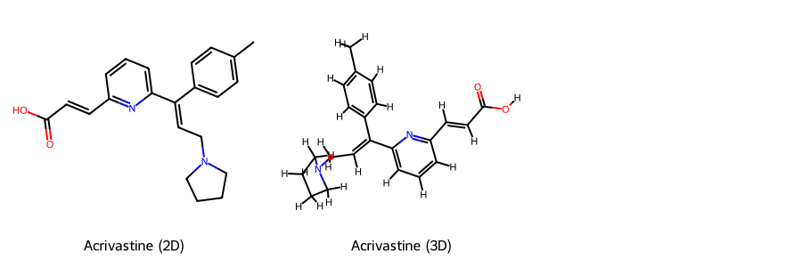

```python
from rdkit.Chem import AllChem  # We need some extra functions from `AllChem`

smiles = r'[H]\C(CN1CCCC1)=C(\C1=CC=C(C)C=C1)C1=CC=CC(=N1)C(\[H])=C(/[H])C(O)=O' # This is the SMILES for Acrivastine
molecule = Chem.MolFromSmiles(smiles)                                            # Molecules read from SMILES are always 2D

# Add hydrogens to create a more realistic molecular model
molecule3d = Chem.AddHs(molecule)

# Generate a single 3D conformation for the molecule
AllChem.EmbedMolecule(molecule3d)

# Draw the result
Draw.MolsToGridImage([molecule, molecule3d], legends=['Acrivastine (2D)', 'Acrivastine (3D)'], subImgSize=(300, 300))
```

To verify if the conformer generation was successful, you can compare the MolBlock outputs for the 2D molecule and its 3D conformation.  
You will see two sets of outputs: one for the 3D conformation with potentially all three x, y, and z coordinates showing variability, and one for the original 2D structure, where z-coordinates are typically zero.

```python
# Output the MolBlock representation of the 3D molecule
print("3D MolBlock" + "-----"*20)
print(Chem.MolToMolBlock(molecule3d))

# To compare, convert the original 2D molecule to a MolBlock and print it
print("2D MolBlock:" + "-----"*20)
print(Chem.MolToMolBlock(molecule))
```

```
3D MolBlock----------------------------------------------------------------------------------------------------

     RDKit          3D

 50 52  0  0  0  0  0  0  0  0999 V2000
   -1.2381   -1.1657    1.0599 C   0  0  0  0  0  0  0  0  0  0  0  0
   -2.6217   -1.3531    1.3840 C   0  0  0  0  0  0  0  0  0  0  0  0
   -3.3863   -2.0665    0.3651 N   0  0  0  0  0  0  0  0  0  0  0  0
   -3.5697   -1.3527   -0.8521 C   0  0  0  0  0  0  0  0  0  0  0  0
   -4.3309   -2.3740   -1.6893 C   0  0  0  0  0  0  0  0  0  0  0  0
   -3.7873   -3.7057   -1.1812 C   0  0  0  0  0  0  0  0  0  0  0  0
   -2.8099   -3.2999   -0.0563 C   0  0  0  0  0  0  0  0  0  0  0  0
   -0.2426   -0.3462    0.8654 C   0  0  0  0  0  0  0  0  0  0  0  0
   -0.5742    1.0499    1.0355 C   0  0  0  0  0  0  0  0  0  0  0  0
   -1.5297    1.6606    1.7556 C   0  0  0  0  0  0  0  0  0  0  0  0
   -1.8463    2.9941    1.7193 C   0  0  0  0  0  0  0  0  0  0  0  0
   -1.1273    3.8243    0.8667 C   0  0  0  0  0  0  0  0  0  0  0  0
   -1.4540    5.2769    0.8112 C   0  0  0  0  0  0  0  0  0  0  0  0
   -0.1427    3.2212    0.1211 C   0  0  0  0  0  0  0  0  0  0  0  0
    0.1437    1.8576    0.1911 C   0  0  0  0  0  0  0  0  0  0  0  0
    1.0820   -0.8172    0.5350 C   0  0  0  0  0  0  0  0  0  0  0  0
    1.4475   -2.1122    0.3356 C   0  0  0  0  0  0  0  0  0  0  0  0
    2.7087   -2.5511    0.0480 C   0  0  0  0  0  0  0  0  0  0  0  0
    3.7408   -1.6419   -0.0613 C   0  0  0  0  0  0  0  0  0  0  0  0
    3.3800   -0.3311    0.1388 C   0  0  0  0  0  0  0  0  0  0  0  0
    2.1226    0.0105    0.4159 N   0  0  0  0  0  0  0  0  0  0  0  0
    4.3316    0.7584    0.0636 C   0  0  0  0  0  0  0  0  0  0  0  0
    5.6121    0.5916   -0.2024 C   0  0  0  0  0  0  0  0  0  0  0  0
    6.5679    1.7001   -0.2762 C   0  0  0  0  0  0  0  0  0  0  0  0
    7.9033    1.5409   -0.5522 O   0  0  0  0  0  0  0  0  0  0  0  0
    6.2233    2.8882   -0.0888 O   0  0  0  0  0  0  0  0  0  0  0  0
   -0.9676   -2.2242    0.9474 H   0  0  0  0  0  0  0  0  0  0  0  0
   -3.2315   -0.4249    1.5604 H   0  0  0  0  0  0  0  0  0  0  0  0
   -2.7671   -1.9293    2.3347 H   0  0  0  0  0  0  0  0  0  0  0  0
   -4.1439   -0.4124   -0.7708 H   0  0  0  0  0  0  0  0  0  0  0  0
   -2.6024   -1.2173   -1.3862 H   0  0  0  0  0  0  0  0  0  0  0  0
   -5.3992   -2.3313   -1.3934 H   0  0  0  0  0  0  0  0  0  0  0  0
   -4.1733   -2.2457   -2.7646 H   0  0  0  0  0  0  0  0  0  0  0  0
   -3.2641   -4.2844   -1.9463 H   0  0  0  0  0  0  0  0  0  0  0  0
   -4.5532   -4.3185   -0.6837 H   0  0  0  0  0  0  0  0  0  0  0  0
```

[output cut: 114 more lines]

```
  8 16  1  0
 16 17  2  0
 17 18  1  0
 18 19  2  0
 19 20  1  0
 20 21  2  0
 20 22  1  0
 22 23  2  0
 23 24  1  0
 24 25  1  0
 24 26  2  0
  7  3  1  0
 15  9  1  0
 21 16  1  0
M  END
```

## Discussion

That concludes our introduction to RDKit. Feel free to add more code cells and experiment with the concepts you've learned.

Now that you are familiar with the basic functionality of RDKit and have a solid grounding in Python, you are well-prepared to tackle more complex tasks. In the next notebook, `03_rdkit_substructure.ipynb`, we will explore how to use **RDKit for substructure searching and filtering**.

You can click here to return to the top and review any topics as needed.